# Analyse des RPU 2012 (version linux)

## Age

```r
summary(d1$AGE)
```

```
##    Min. 1st Qu.  Median    Mean 3rd Qu.    Max.    NA's
##     0.0    23.0    42.0    44.2    65.0   129.0      36
```

```r
age0 <- length(d1[d1$AGE < 1, "AGE"])
age75 <- length(d1[d1$AGE > 75, "AGE"])
age1_75 <- length(d1[d1$AGE > 0 & d1$AGE < 76, "AGE"])
effectif <- c(age0, age1_75, age75)
pourcentage <- round(pop * 100/sum(pop), 2)
```

```
## Error: objet 'pop' introuvable
```

```r
t <- data.frame(effectif, pourcentage, row.names = c("moins de 1 an", "de 1 à 75 ans",
    "plus de 75 ans"))
```

```
## Error: objet 'pourcentage' introuvable
```

## Gravité

```r
table(d1$GRAVITE, useNA = "ifany")
```

```
##
##     1     2     3     4     5     D     P  <NA>
## 21081 82785 13925  1619   390     9  1325 21242
```

```r
freq(d1$GRAVITE)
```

```
##        n    %
## 1  21081 14.8
## 2  82785 58.1
## 3  13925  9.8
## 4   1619  1.1
## 5    390  0.3
## D      9  0.0
## P   1325  0.9
## NA 21242 14.9
```

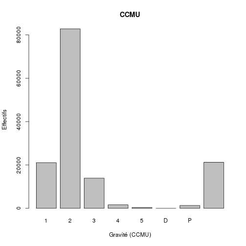

```r
barplot(table(d1$GRAVITE, useNA = "ifany"), xlab = "Gravité (CCMU)", ylab = "Effectifs",
    main = "CCMU")
```

### gravité et sexe

```r
t <- table(d1$GRAVITE, d1$SEXE)
round(prop.table(t) * 100, 3)
```

```
##
##          F      M
##   1  8.119  9.274
##   2 32.579 35.773
##   3  5.639  5.857
##   4  0.661  0.675
##   5  0.135  0.187
##   D  0.002  0.006
##   P  0.576  0.516
```

```r
addmargins(t)
```

```
##
##            F      M    Sum
##   1     9832  11230  21062
##   2    39452  43320  82772
##   3     6829   7093  13922
##   4      801    818   1619
##   5      163    227    390
##   D        2      7      9
##   P      698    625   1323
##   Sum  57777  63320 121097
```

```r
round(addmargins(prop.table(t) * 100), 3)
```

```
##
##             F       M     Sum
##   1     8.119   9.274  17.393
##   2    32.579  35.773  68.352
##   3     5.639   5.857  11.497
##   4     0.661   0.675   1.337
##   5     0.135   0.187   0.322
##   D     0.002   0.006   0.007
##   P     0.576   0.516   1.093
##   Sum  47.711  52.289 100.000
```

### gravité et age

Moyenne et ecart-type:

```r
round(tapply(d1$AGE, d1$GRAVITE, mean, na.rm = TRUE), 2)
```

```
##     1     2     3     4     5     D     P
## 36.77 41.07 56.48 66.94 63.62 69.33 41.93
```

```r
round(tapply(d1$AGE, d1$GRAVITE, sd, na.rm = TRUE), 2)
```

```
##     1     2     3     4     5     D     P
## 24.69 25.18 27.16 21.70 19.99 25.94 16.72
```

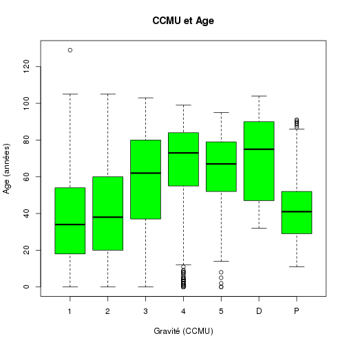

```r
boxplot(d1$AGE ~ d1$GRAVITE, xlab = "Gravité (CCMU)", ylab = "Age (années)",
    main = "CCMU et Age", col = "green")
```

### gravité et Finess

```r
t <- table(d1$FINESS, d1$GRAVITE)
t
```

```
##
##           1     2     3     4     5     D     P
##   Wis   644  6619   345    59    22     1    15
##   Sel  2762 17781  4414   556    55     1   147
##   Odi   668 11503   110     3     1     1     1
##   Hus  2848  8676  3517   621   108     0     1
##   Hag   103   461    88     8     4     0     0
##   3Fr   905  6212    74     0     1     0     1
##   Alk    22   107    12     5     2     0     0
##   Col 12947 26727  5355   363   197     4  1147
##   Geb   182  4699    10     4     0     2    13
```

```r
a <- round(prop.table(t) * 100, 3)
a
```

```
##
##            1      2      3      4      5      D      P
##   Wis  0.532  5.464  0.285  0.049  0.018  0.001  0.012
##   Sel  2.280 14.679  3.644  0.459  0.045  0.001  0.121
##   Odi  0.551  9.496  0.091  0.002  0.001  0.001  0.001
##   Hus  2.351  7.162  2.903  0.513  0.089  0.000  0.001
##   Hag  0.085  0.381  0.073  0.007  0.003  0.000  0.000
##   3Fr  0.747  5.128  0.061  0.000  0.001  0.000  0.001
##   Alk  0.018  0.088  0.010  0.004  0.002  0.000  0.000
##   Col 10.688 22.064  4.421  0.300  0.163  0.003  0.947
##   Geb  0.150  3.879  0.008  0.003  0.000  0.002  0.011
```

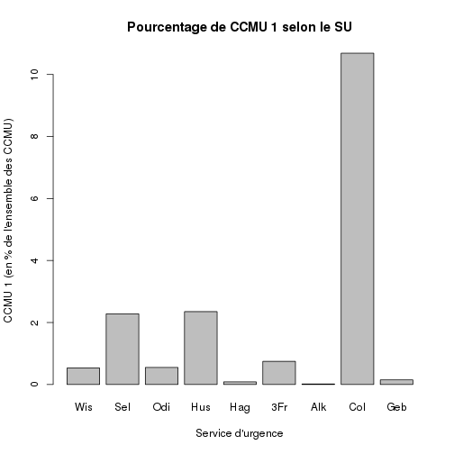

```r
barplot(a[, 1], main = "Pourcentage de CCMU 1 selon le SU", xlab = "Service d'urgence",
    ylab = "CCMU 1 (en % de l'ensemble des CCMU)")
```

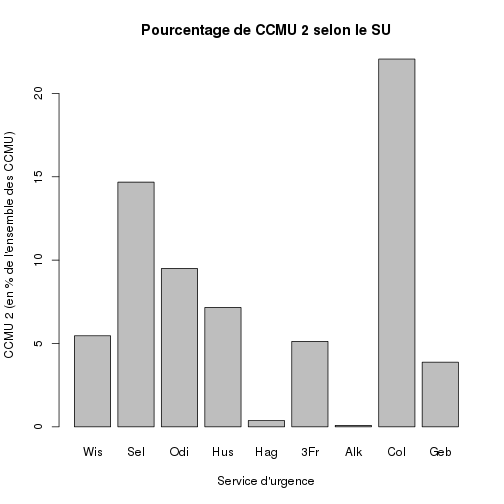

```r
barplot(a[, 2], main = "Pourcentage de CCMU 2 selon le SU", xlab = "Service d'urgence",
    ylab = "CCMU 2 (en % de l'ensemble des CCMU)")
```

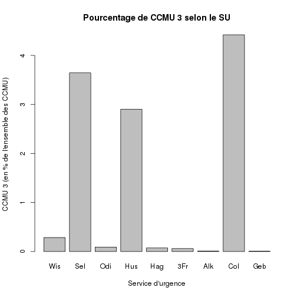

```r
barplot(a[, 3], main = "Pourcentage de CCMU 3 selon le SU", xlab = "Service d'urgence",
    ylab = "CCMU 3 (en % de l'ensemble des CCMU)")
```

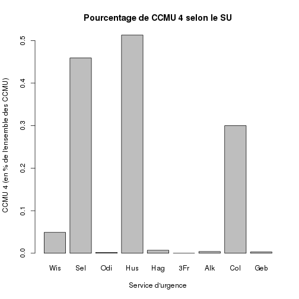

```r
barplot(a[, 4], main = "Pourcentage de CCMU 4 selon le SU", xlab = "Service d'urgence",
    ylab = "CCMU 4 (en % de l'ensemble des CCMU)")
```

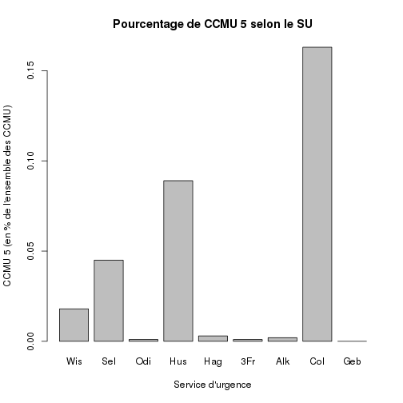

```r
barplot(a[, 5], main = "Pourcentage de CCMU 5 selon le SU", xlab = "Service d'urgence",
    ylab = "CCMU 5 (en % de l'ensemble des CCMU)")
```

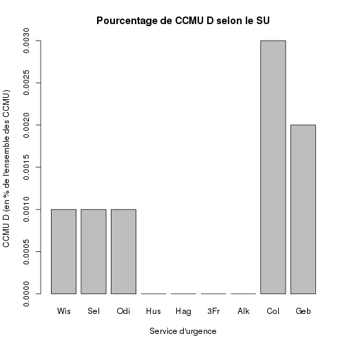

```r
barplot(a[, 6], main = "Pourcentage de CCMU D selon le SU", xlab = "Service d'urgence",
    ylab = "CCMU D (en % de l'ensemble des CCMU)")
```

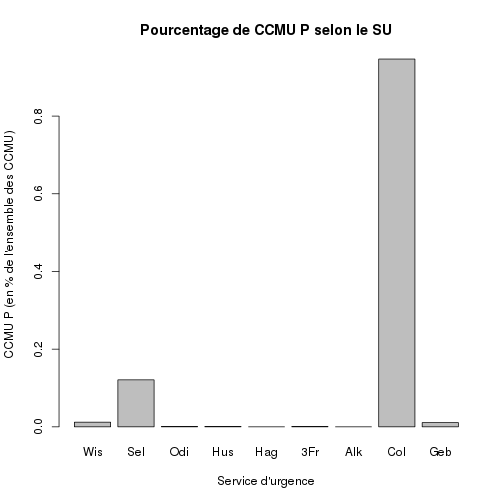

```r
barplot(a[, 7], main = "Pourcentage de CCMU P selon le SU", xlab = "Service d'urgence",
    ylab = "CCMU P (en % de l'ensemble des CCMU)")
```

```r
round(addmargins(prop.table(t) * 100), 3)
```

```
##
##             1       2       3       4       5       D       P     Sum
##   Wis   0.532   5.464   0.285   0.049   0.018   0.001   0.012   6.361
##   Sel   2.280  14.679   3.644   0.459   0.045   0.001   0.121  21.229
##   Odi   0.551   9.496   0.091   0.002   0.001   0.001   0.001  10.143
##   Hus   2.351   7.162   2.903   0.513   0.089   0.000   0.001  13.019
##   Hag   0.085   0.381   0.073   0.007   0.003   0.000   0.000   0.548
##   3Fr   0.747   5.128   0.061   0.000   0.001   0.000   0.001   5.938
##   Alk   0.018   0.088   0.010   0.004   0.002   0.000   0.000   0.122
##   Col  10.688  22.064   4.421   0.300   0.163   0.003   0.947  38.585
##   Geb   0.150   3.879   0.008   0.003   0.000   0.002   0.011   4.053
##   Sum  17.403  68.342  11.496   1.337   0.322   0.007   1.094 100.000
```

## Destination

```r
table(d1$DESTINATION, useNA = "ifany")
```

```
##
##     NA    MCO    SSR    SLD    PSY    HAD    HMS   <NA>
##      0  38365     22      9    745      1      3 103231
```

```r
freq(d1$DESTINATION)
```

```
##          n    %
## MCO  38365 26.9
## SSR     22  0.0
## SLD      9  0.0
## PSY    745  0.5
## HAD      1  0.0
## HMS      3  0.0
## NA  103231 72.5
```

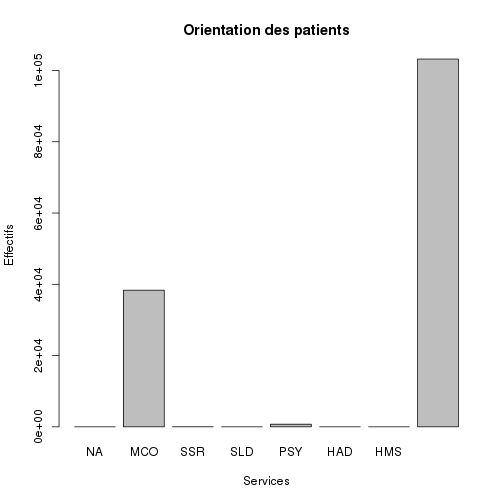

```r
barplot(table(d1$DESTINATION, useNA = "ifany"), xlab = "Services", ylab = "Effectifs",
    main = "Orientation des patients")
```

## FINESS

```r
t <- table(d1$FINESS, useNA = "ifany")
t
```

```
##
##   Wis   Sel   Odi   Hus   Hag   3Fr   Alk   Col   Geb
##  7711 26339 12354 35889   725  7342   169 46927  4920
```

```r
round(prop.table(t) * 100, 2)
```

```
##
##   Wis   Sel   Odi   Hus   Hag   3Fr   Alk   Col   Geb
##  5.42 18.50  8.68 25.21  0.51  5.16  0.12 32.96  3.46
```

```r
freq(d1$FINESS)
```

```
##         n    %
## Wis  7711  5.4
## Sel 26339 18.5
## Odi 12354  8.7
## Hus 35889 25.2
## Hag   725  0.5
## 3Fr  7342  5.2
## Alk   169  0.1
## Col 46927 33.0
## Geb  4920  3.5
## NA      0  0.0
```

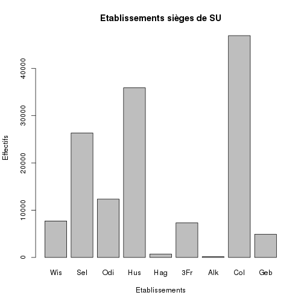

```r
barplot(table(d1$FINESS, useNA = "ifany"), xlab = "Etablissements", ylab = "Effectifs",
    main = "Etablissements sièges de SU")
```

## Mode d'entrée

```r
table(d1$MODE_ENTREE, useNA = "ifany")
```

```
##
##        NA  Mutation Transfert  Domicile      <NA>
##         0      2515      2035    132743      5083
```

```r
freq(d1$MODE_ENTREE)
```

```
##                n    %
## Mutation    2515  1.8
## Transfert   2035  1.4
## Domicile  132743 93.2
## NA          5083  3.6
```

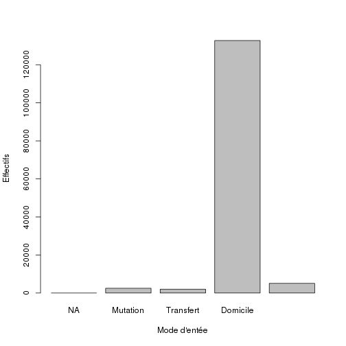

```r
barplot(table(d1$MODE_ENTREE, useNA = "ifany"), xlab = "Mode d'entée", ylab = "Effectifs",
    main = "")
```

## Mode de sortie

```r
table(d1$MODE_SORTIE, useNA = "ifany")
```

```
##
##        NA  Mutation Transfert  Domicile     Décès      <NA>
##         0     37797      1386     81724         1     21468
```

```r
freq(d1$MODE_SORTIE)
```

```
##               n    %
## Mutation  37797 26.5
## Transfert  1386  1.0
## Domicile  81724 57.4
## Décès         1  0.0
## NA        21468 15.1
```

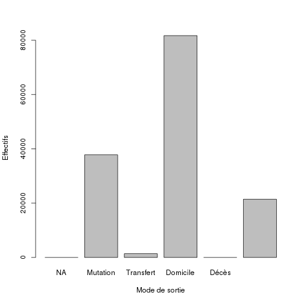

```r
barplot(table(d1$MODE_SORTIE, useNA = "ifany"), xlab = "Mode de sortie", ylab = "Effectifs",
    main = "")
```

## Orientation

La rubrique *ORIENTATION* comporte un certain nombre d'éléments aberrants qui perturbent son interprétation comme facteur. Dans un premier temps, on ne retient que les valeurs comportant moins de dix caractères, puis on transforme la rubrique en facteur:

```r
b <- d1$ORIENTATION[nchar(d1$ORIENTATION) < 10]
d1$ORIENTATION <- as.factor(b)
```

```
## Error: replacement has 142344 rows, data has 142376
```

La ligne précédente génére une erreur car *b* comporte moins de lignes que *d1* puisqu'on a retiré les éléments comportants plus de 10 caractères.

Il reste encore quelques intitulés anormaux: M, F, REO?

On suppose également que les *NA* correspondent aux patients non hospitalisés. On crée un dataframe des patients hospitalisés après leur passage aux urgences

```r
a <- b[!is.na(b)]
```

nombre de patients hospitalisés:

```r
length(a)
```

```
## [1] 40768
```

Taux d'hospitalisation:

```r
round(length(a) * 100/nrow(d1), 2)
```

```
## [1] 28.63
```

Transformation en facteur et analyse:

```r
hospit <- factor(a)
hospit[hospit == "M" | hospit == "F"] <- NA  # on supprime M et F
summary(hospit)
```

```
##  CHIR     F FUGUE   HDT    HO     M   MED  OBST   PSA   REA   REO    SC
##  4017     0   133    88    12     0  8162    26   948   431  1332   212
##  SCAM    SI  UHCD  NA's
##   215   583 24605     4
```

```r
f <- freq(hospit, sort = "inc", digits = 2)
f
```

```
##           n     %
## NA        4  0.01
## HO       12  0.03
## OBST     26  0.06
## HDT      88  0.22
## FUGUE   133  0.33
## SC      212  0.52
## SCAM    215  0.53
## REA     431  1.06
## SI      583  1.43
## PSA     948  2.33
## REO    1332  3.27
## CHIR   4017  9.85
## MED    8162 20.02
## UHCD  24605 60.35
```

```r
t <- table(hospit)
sort(t)
```

```
## hospit
##     F     M    HO  OBST   HDT FUGUE    SC  SCAM   REA    SI   PSA   REO
##     0     0    12    26    88   133   212   215   431   583   948  1332
##  CHIR   MED  UHCD
##  4017  8162 24605
```

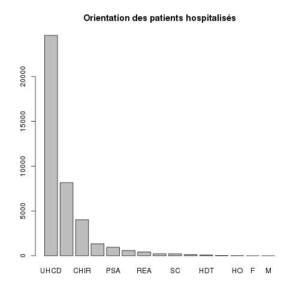

```r
barplot(sort(t, decreasing = TRUE), main = "Orientation des patients hospitalisés")
```

on forme deux nouveaux dataframe qui ne prennent pas en compte les lignes anormales et ne retiennent que les patients hospitalisés (*hop*) ou non hospitalisés (*nonhop*):

```r
hop <- d1[nchar(d1$ORIENTATION) < 10, -1]
hop$ORIENTATION <- as.factor(hop$ORIENTATION)
hop$GRAVITE <- as.factor(hop$GRAVITE)
nonhop <- hop[is.na(hop$ORIENTATION), ]
hop <- hop[!is.na(hop$ORIENTATION), ]

summary(nonhop$GRAVITE)
```

```
##     1     2     3     4     5     D     P  NA's
## 16389 67680  2366   199    53     9   795 14085
```

```r
summary(hop$GRAVITE)
```

```
##     1     2     3     4     5     D     P  NA's
##  4674 15093 11557  1420   337     0   530  7157
```

TODO:

- créer une colonne supplémentaire dans D1 pour marquer ceux qui sont hospitalisé de ceux qui ne le sont pas
- caractéristiques (age, sexe, CCMU) des hospitalisés versus les non hospialisés
- y a t'il des hopitaux qui hospitalisent plus que d'autres ?

## Provenance

```r
table(d1$PROVENANCE, useNA = "ifany")
```

```
##
##    NA   MCO   SSR   SLD   PSY   PEA   PEO  <NA>
##     0  4504    26    15    22 90248   895 46666
```

```r
freq(d1$PROVENANCE)
```

```
##         n    %
## MCO  4504  3.2
## SSR    26  0.0
## SLD    15  0.0
## PSY    22  0.0
## PEA 90248 63.4
## PEO   895  0.6
## NA  46666 32.8
```

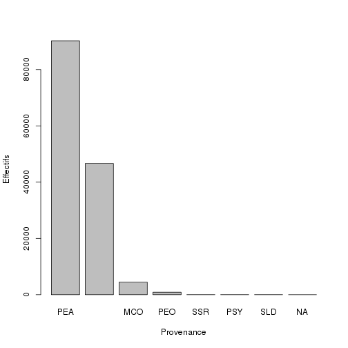

```r
barplot(sort(table(d1$PROVENANCE, useNA = "ifany"), decreasing = TRUE), xlab = "Provenance",
    ylab = "Effectifs", main = "")
```

## Transport

```r
table(d1$TRANSPORT, useNA = "ifany")
```

```
##
##        AMBU    FO  HELI PERSO  SMUR  VSAB  <NA>
##    36 21393   693    70 67336  2095 12179 38574
```

```r
freq(d1$TRANSPORT)
```

```
##           n    %
##          36  0.0
## AMBU  21393 15.0
## FO      693  0.5
## HELI     70  0.0
## PERSO 67336 47.3
## SMUR   2095  1.5
## VSAB  12179  8.6
## NA    38574 27.1
```

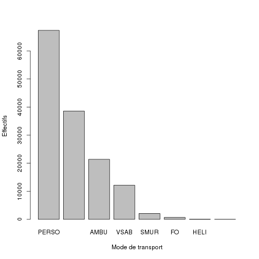

```r
barplot(sort(table(d1$TRANSPORT, useNA = "ifany"), decreasing = TRUE), xlab = "Mode de transport",
    ylab = "Effectifs", main = "")
```

## Prise en charge

Note: *freq* nécessite *rgrs*. Réalise le tri à plat d'une variable. Permet aussi d'afficher le % cumulé, d'exclure certaines variables du tri, d'afficher l'effectif total et de préciser le nombre de chiffres significatifs.

```r
table(d1$TRANSPORT_PEC, useNA = "ifany")
```

```
##
##           AUCUN     MED    NULL PARAMED
##      36   90600    4777   42649    4314
```

```r
f <- freq(d1$TRANSPORT_PEC, sort = "inc", exclude = c(NA, ""), total = TRUE)
f
```

```
##              n     %
## PARAMED   4314   3.0
## MED       4777   3.4
## NULL     42649  30.0
## AUCUN    90600  63.7
## Total   142340 100.0
```

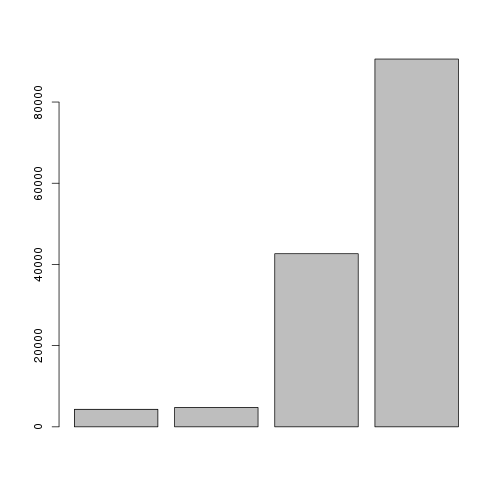

```r
barplot(f[1:nrow(f) - 1, 1])
```

```r
row.names(f)
```

```
## [1] "PARAMED" "MED"     "NULL"    "AUCUN"   "Total"
```

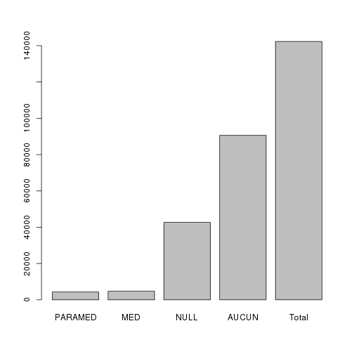

```r
barplot(f[1:nrow(f), 1], names.arg = row.names(f))
```

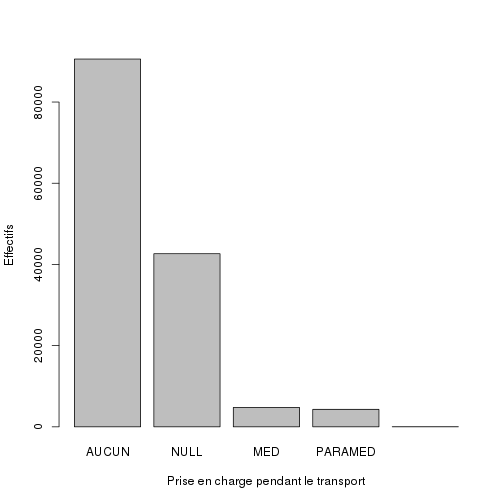

```r
t <- table(d1$TRANSPORT_PEC)
barplot(sort(t, decreasing = TRUE), xlab = "Prise en charge pendant le transport",
    ylab = "Effectifs", main = "")
```

# Analyse bivariée

### Age et sexe

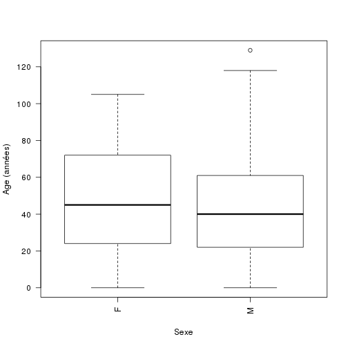

```r
boxplot(d1$AGE ~ d1$SEXE, ylab = "Age (années)", xlab = "Sexe", las = 2)
```

## Age et Gravité

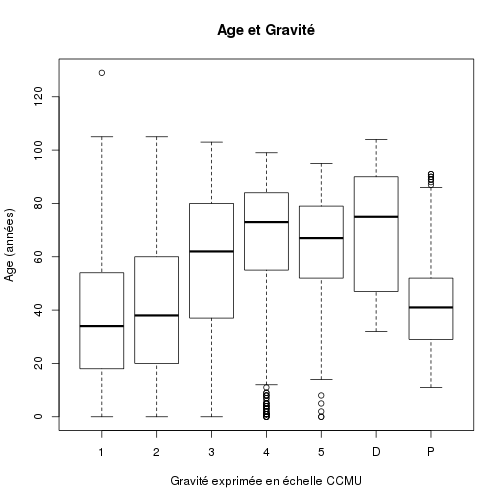

```r
boxplot(d1$AGE ~ d1$GRAVITE, xlab = "Gravité exprimée en échelle CCMU", ylab = "Age (années)",
    main = "Age et Gravité")
```

## Age et FINESS

Les HUS ont une patientèle plus agée que la moyenne:

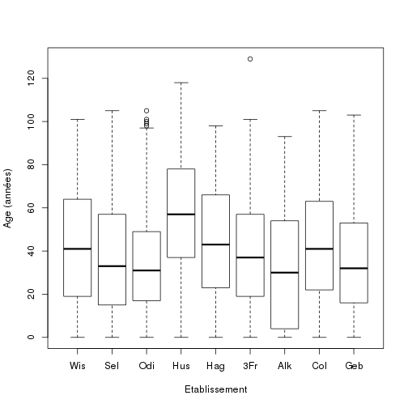

```r
boxplot(d1$AGE ~ d1$FINESS, xlab = "Etablissement", ylab = "Age (années)")
```

```r
round(tapply(d1$AGE, d1$FINESS, mean, na.rm = TRUE), 2)
```

```
##   Wis   Sel   Odi   Hus   Hag   3Fr   Alk   Col   Geb
## 42.58 37.70 34.04 56.48 44.36 39.00 33.41 43.09 36.46
```

Pour rendre le graphique plus parlant, on réorganise les boxplots pour qu'ils soient affichés par moyenne d'age croissante. D'abord on réorganise les FINESS avec la fonction *reorder* qui demande trois paramètres: le variable factor à reorganiser (finess), la variable qui servira de supoort à la réorganisation (age) et la fonction de tri (mean). S'agissant de la moyenne ne pas oublier na.rm=TRUE pour éviter un affichage aberrant. Puis on affiche les boxplots par ordre de moyenne d'age croissant.

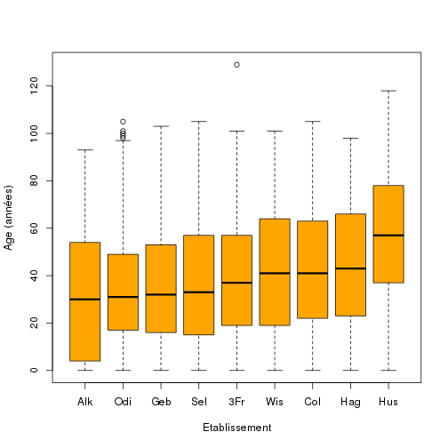

```r
a <- with(d1, reorder(FINESS, AGE, mean, na.rm = TRUE))
boxplot(AGE ~ a, data = d1, xlab = "Etablissement", ylab = "Age (années)",
    col = "orange")
```

## Age et établissement

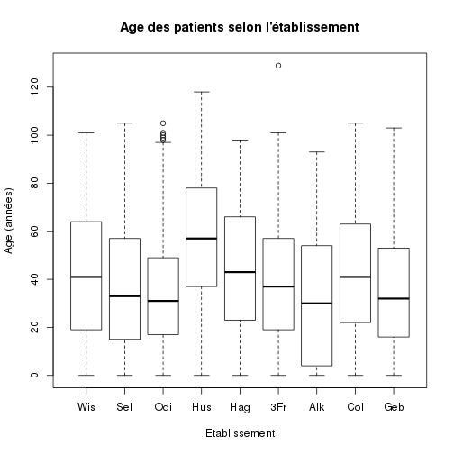

```r
boxplot(d1$AGE ~ d1$FINESS, ylab = "Age (années)", xlab = "Etablissement",
    main = "Age des patients selon l'établissement")
```

# FINESS

### FINESS et GRAVITE

```
## Error: les longueurs de 'at' et de 'labels' diffèrent, 21 != 53454
```

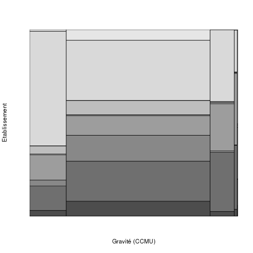

```r
plot(d1$FINESS ~ d1$GRAVITE, ylab = "Etablissement", xlab = "Gravité (CCMU)")
```

```r
a <- table(d1$FINESS, d1$GRAVITE)
addmargins(a)
```

```
##
##            1      2      3      4      5      D      P    Sum
##   Wis    644   6619    345     59     22      1     15   7705
##   Sel   2762  17781   4414    556     55      1    147  25716
##   Odi    668  11503    110      3      1      1      1  12287
##   Hus   2848   8676   3517    621    108      0      1  15771
##   Hag    103    461     88      8      4      0      0    664
##   3Fr    905   6212     74      0      1      0      1   7193
##   Alk     22    107     12      5      2      0      0    148
##   Col  12947  26727   5355    363    197      4   1147  46740
##   Geb    182   4699     10      4      0      2     13   4910
##   Sum  21081  82785  13925   1619    390      9   1325 121134
```

```r
round(prop.table(a) * 100, digit = 2)
```

```
##
##           1     2     3     4     5     D     P
##   Wis  0.53  5.46  0.28  0.05  0.02  0.00  0.01
##   Sel  2.28 14.68  3.64  0.46  0.05  0.00  0.12
##   Odi  0.55  9.50  0.09  0.00  0.00  0.00  0.00
##   Hus  2.35  7.16  2.90  0.51  0.09  0.00  0.00
##   Hag  0.09  0.38  0.07  0.01  0.00  0.00  0.00
##   3Fr  0.75  5.13  0.06  0.00  0.00  0.00  0.00
##   Alk  0.02  0.09  0.01  0.00  0.00  0.00  0.00
##   Col 10.69 22.06  4.42  0.30  0.16  0.00  0.95
##   Geb  0.15  3.88  0.01  0.00  0.00  0.00  0.01
```

Gavité et établissement: les fréquences sont exprimées en pourcentage. La somme de chaque ligne est égale à 100%.

```r
addmargins(round(prop.table(a, margin = 1) * 100, digit = 2), margin = 2)
```

```
##
##            1      2      3      4      5      D      P    Sum
##   Wis   8.36  85.91   4.48   0.77   0.29   0.01   0.19 100.01
##   Sel  10.74  69.14  17.16   2.16   0.21   0.00   0.57  99.98
##   Odi   5.44  93.62   0.90   0.02   0.01   0.01   0.01 100.01
##   Hus  18.06  55.01  22.30   3.94   0.68   0.00   0.01 100.00
##   Hag  15.51  69.43  13.25   1.20   0.60   0.00   0.00  99.99
##   3Fr  12.58  86.36   1.03   0.00   0.01   0.00   0.01  99.99
##   Alk  14.86  72.30   8.11   3.38   1.35   0.00   0.00 100.00
##   Col  27.70  57.18  11.46   0.78   0.42   0.01   2.45 100.00
##   Geb   3.71  95.70   0.20   0.08   0.00   0.04   0.26  99.99
```

Avec code de couleur:

```
## Error: les longueurs de 'at' et de 'labels' diffèrent, 21 != 53454
```

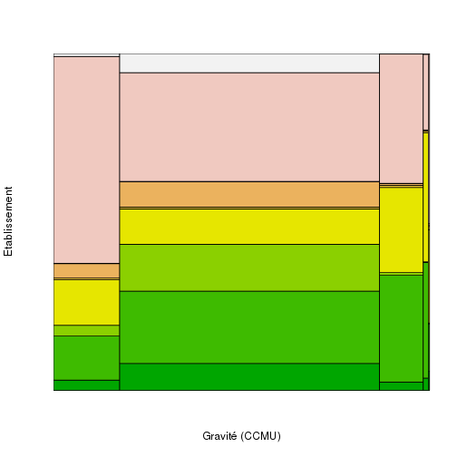

```r
plot(d1$FINESS ~ d1$GRAVITE, ylab = "Etablissement", xlab = "Gravité (CCMU)",
    col = terrain.colors(n = 9))
```

Même calcul en supprimant Hag et Alk dont la contribution est négligeable: (nécessite le package gdata)

```r
d2 <- d1[d1$FINESS != "Hag" & d1$FINESS != "Alk", c(8, 9)]
d2$FINESS <- drop.levels(d2$FINESS)
summary(d2$FINESS)
```

```
##   3Fr   Col   Geb   Hus   Odi   Sel   Wis
##  7342 46927  4920 35889 12354 26339  7711
```

```
## Error: les longueurs de 'at' et de 'labels' diffèrent, 21 != 53153
```

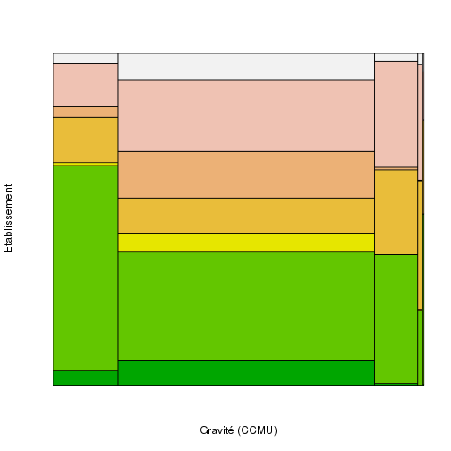

```r
plot(d2$FINESS ~ d2$GRAVITE, ylab = "Etablissement", xlab = "Gravité (CCMU)",
    col = terrain.colors(n = 7))
```

# Gestion du temps

## Répartition par mois

Pas interprétable compte tenu de la montée en puissance progressive en 2012

```r
m <- month(d1$ENTREE, label = TRUE)
table(m)
```

```
## m
##   Jan   Feb   Mar   Apr   May   Jun   Jul   Aug   Sep   Oct   Nov   Dec
##  3768  3758  7213 10637 10652 11748 14613 14637 15294 16487 16194 17375
```

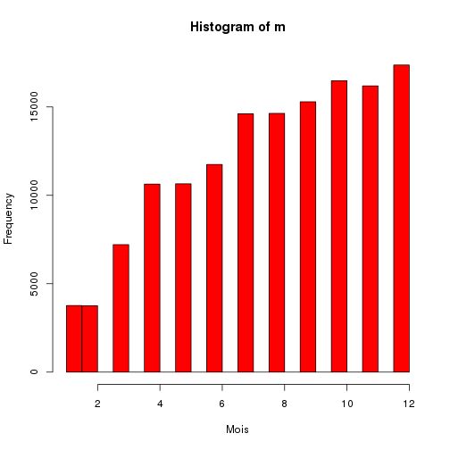

```r
m <- month(d1$ENTREE)
hist(m, xlab = "Mois", col = "red")
```

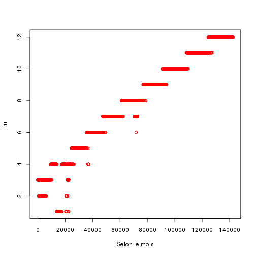

```r
plot(m, xlab = "Selon le mois", col = "red")
```

## Répartition par jour de la semaine

```r
w <- wday(d1$ENTREE, label = TRUE)
table(w)
```

```
## w
##   Sun   Mon  Tues   Wed Thurs   Fri   Sat
## 21359 21800 19680 19385 19362 19790 21000
```

```r
round(prop.table(table(w)) * 100, 2)
```

```
## w
##   Sun   Mon  Tues   Wed Thurs   Fri   Sat
## 15.00 15.31 13.82 13.62 13.60 13.90 14.75
```

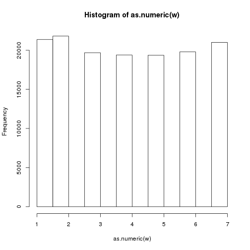

```r
hist(as.numeric(w))
```

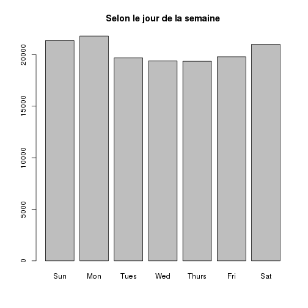

```r
plot(w, main = "Selon le jour de la semaine")
```

## Répartition par heure de la journée

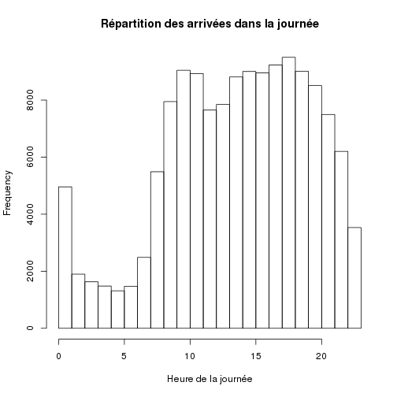

```r
h <- hour(d1$ENTREE)
hist(h, breaks = 24, xlab = "Heure de la journée", main = "Répartition des arrivées dans la journée")
```

## Transformation des factor en heure

```r
e <- ymd_hms(as.character(d1$ENTREE))
s <- ymd_hms(as.character(SORTIE))
d <- s - e
dmin <- d/60
summary(as.numeric(dmin))
```

```
##    Min. 1st Qu.  Median    Mean 3rd Qu.    Max.    NA's
##   -1140      38      93     140     181    8800   13791
```

```r
dmin <- as.numeric(d/60)
a <- dmin[dmin < 0]
length(a)
```

```
## [1] 13831
```

```r
a <- dmin[dmin > 0]
length(a)
```

```
## [1] 142292
```

```r
summary(a)
```

```
##    Min. 1st Qu.  Median    Mean 3rd Qu.    Max.    NA's
##       1      38      93     140     181    8800   13791
```

```r
b <- dmin[dmin > 1440]
length(b)
```

```
## [1] 14099
```

Recodage du temps de présence à partir de dmin. Si dmin <=0 c'est que l'heure de sortie est inconnue. Au dela de 5 jours, le séjour est classé *HL* (hors limites)

```r
d1$sejour[dmin <= 0] <- NA
d1$sejour[dmin > 0 & dmin <= 1440 & !is.na(dmin)] <- "H24"
d1$sejour[dmin > 1440 & dmin <= 2880] <- "H48"
d1$sejour[dmin > 2880 & dmin <= 4320] <- "H72"
d1$sejour[dmin > 4320 & dmin <= 5760] <- "H96"
d1$sejour[dmin > 5760 & dmin <= 7200] <- "H120"
d1$sejour[dmin > 7200] <- "HL"
d1$sejour <- factor(d1$sejour, order = TRUE, levels = c("H24", "H48", "H72",
    "H96", "H120", "HL"))
levels(d1$sejour)
```

```
## [1] "H24"  "H48"  "H72"  "H96"  "H120" "HL"
```

```r
summary(d1$sejour)
```

```
##    H24    H48    H72    H96   H120     HL   NA's
## 128193    248     22     31      5      2  13875
```

```r
t <- table(d1$sejour)
round(prop.table(t) * 100, 3)
```

```
##
##    H24    H48    H72    H96   H120     HL
## 99.760  0.193  0.017  0.024  0.004  0.002
```

Création d'une nouvelle variable *time* qui mesure le temps de présence en minute (SORTIE - ENTREE)

```r
d1$time <- dmin
```

Séjours de 24 heures

```r
s24 <- d1[d1$sejour == "H24" & !is.na(d1$sejour), ]
nrow(s24)
```

```
## [1] 128193
```

```r
t <- tapply(s24$time, s24$FINESS, summary)
t
```

```
## $Wis
##    Min. 1st Qu.  Median    Mean 3rd Qu.    Max.
##       1      43      82     121     149    1430
##
## $Sel
##    Min. 1st Qu.  Median    Mean 3rd Qu.    Max.
##       1      73     119     145     192     852
##
## $Odi
##    Min. 1st Qu.  Median    Mean 3rd Qu.    Max.
##       2      43      72      86     113    1440
##
## $Hus
##    Min. 1st Qu.  Median    Mean 3rd Qu.    Max.
##     1.0     1.0     1.0    76.8     1.0  1440.0
##
## $Hag
##    Min. 1st Qu.  Median    Mean 3rd Qu.    Max.
##       2     112     197     277     328    1370
##
## $`3Fr`
##    Min. 1st Qu.  Median    Mean 3rd Qu.    Max.
##       2      54      95     115     149    1440
##
## $Alk
##    Min. 1st Qu.  Median    Mean 3rd Qu.    Max.
##      34     101     160     203     278     817
##
## $Col
##    Min. 1st Qu.  Median    Mean 3rd Qu.    Max.
##       1      77     142     182     251    1440
##
## $Geb
##    Min. 1st Qu.  Median    Mean 3rd Qu.    Max.
##     2.0    30.0    49.0    68.3    78.0  1440.0
```

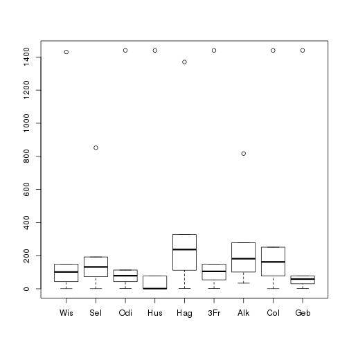

```r
boxplot(t)
```

cas particulier des HUS. Nombre de dossier Hus où la durée de séjour est de moins de 24 heures:

```r
nt <- length(s24$time[s24$FINESS == "Hus"])
nt
```

```
## [1] 23053
```

nombre de dossiers où la durée de séjour est de 1 minute:

```r
n1 <- length(s24$time[s24$FINESS == "Hus" & s24$time == 1])
n1
```

```
## [1] 19929
```

```r
round(n1 * 100/nt, 2)
```

```
## [1] 86.45
```

nombre de dossiers où la durée de séjour est inférieure à 30 minutes:

```r
n30 <- length(s24$time[s24$FINESS == "Hus" & s24$time < 30])
n30
```

```
## [1] 19965
```

```r
round(n30 * 100/nt, 2)
```

```
## [1] 86.6
```

Séjours de 24 heures renseignés:

```r
length(s24$time[s24$FINESS == "Hus" & s24$time > 30])
```

```
## [1] 3086
```

```r
a <- s24[s24$FINESS == "Hus" & s24$time > 30, ]
summary(a$time)
```

```
##    Min. 1st Qu.  Median    Mean 3rd Qu.    Max.
##      31     183     322     567    1080    1440
```

```r
summary(a)
```

```
##                                 id        CODE_POSTAL
##  2c9d838436119ed90136119ee0280001:   1   67000  : 673
##  2c9d838436119ed90136119ee0510002:   1   67200  : 495
##  2c9d838436119ed90136119ee05b0003:   1   67100  : 365
##  2c9d838436119ed90136119ee0790004:   1   67300  : 169
##  2c9d838436119ed90136119ee0860005:   1   67800  : 126
##  2c9d838436119ed90136119ee08d0006:   1   67400  :  97
##  (Other)                         :3080   (Other):1161
##                    COMMUNE      DESTINATION        DP
##  STRASBOURG            :1533   MCO    : 354   Length:3086
##  SCHILTIGHEIM          : 169   NA     :   0   Class :character
##  ILLKIRCH GRAFFENSTADEN:  97   SSR    :   0   Mode  :character
##  BISCHHEIM             :  82   SLD    :   0
##  LINGOLSHEIM           :  72   PSY    :   0
##  HOENHEIM              :  44   (Other):   0
##  (Other)               :1089   NA's   :2732
##     ENTREE                         EXTRACT         FINESS
##  Length:3086        2012-02-21 23:00:02:  44   Hus    :3086
##  Class :character   2012-02-27 23:00:00:  44   Wis    :   0
##  Mode  :character   2012-03-13 23:00:02:  43   Sel    :   0
##                     2012-03-03 23:00:02:  37   Odi    :   0
##                     2012-04-25 23:00:04:  36   Hag    :   0
##                     2012-04-29 23:00:04:  29   3Fr    :   0
##                     (Other)            :2853   (Other):   0
##    GRAVITE             MODE_ENTREE      MODE_SORTIE      MOTIF
##  Length:3086        NA       :   0   NA       :   0   Length:3086
##  Class :character   Mutation :   8   Mutation : 354   Class :character
##  Mode  :character   Transfert:   3   Transfert:   0   Mode  :character
##                     Domicile :3075   Domicile : 770
##                                      Décès    :   0
##                                      NA's     :1962
##
##    NAISSANCE          ORIENTATION          PROVENANCE   SEXE
##  Min.   :1912-03-05   Length:3086        MCO    :   9   F:1454
##  1st Qu.:1950-04-05   Class :character   SLD    :   1   M:1632
##  Median :1969-12-17   Mode  :character   PSY    :   1
##  Mean   :1966-02-01                      NA     :   0
##  3rd Qu.:1984-10-07                      SSR    :   0
##  Max.   :2012-08-07                      (Other):   0
##                                          NA's   :3075
##     SORTIE           TRANSPORT         TRANSPORT_PEC       AGE
##  Length:3086        Length:3086               :   0   Min.   :  0
##  Class :character   Class :character   AUCUN  : 488   1st Qu.: 27
##  Mode  :character   Mode  :character   MED    :  14   Median : 42
##                                        NULL   :2583   Mean   : 46
##                                        PARAMED:   1   3rd Qu.: 62
##                                                       Max.   :100
##
##   sejour          time
##  H24 :3086   Min.   :  31
##  H48 :   0   1st Qu.: 183
##  H72 :   0   Median : 322
##  H96 :   0   Mean   : 567
##  H120:   0   3rd Qu.:1081
##  HL  :   0   Max.   :1440
##
```

# Analyse du code postal

Patients non originaire de l'Alsace:

```r
a <- d1[as.character(d1$CODE_POSTAL) < "67000" | as.character(d1$CODE_POSTAL) >
    "68999", ]
nrow(a)
```

```
## [1] 5629
```

dans quel hôpitaux:

```r
summary(a$FINESS)
```

```
##  Wis  Sel  Odi  Hus  Hag  3Fr  Alk  Col  Geb
##  301  904  251 1316   34  283    2 2401  137
```

dont non français:

```r
length(a$CODE_POSTAL[as.character(a$CODE_POSTAL) == "99999"])
```

```
## [1] 928
```

```r
length(a$CODE_POSTAL[as.character(a$CODE_POSTAL) > "99000"])
```

```
## [1] 1431
```

```r
b <- unique(a$CODE_POSTAL[as.character(a$CODE_POSTAL) > "99000"])
length(b)
```

```
## [1] 61
```

```r
b <- unique(a$COMMUNE[as.character(a$CODE_POSTAL) > "99000"])
sort(b)
```

```
##   [1] 0                                00000000
##   [3] 00370 HELSINKI                   00537 ARMEES
##   [5] 00597 ARMEES                     0099 AZERBAIDJAN
##   [7] 01705 FREITAL                    02003 NICOSIE CHYPRE
##   [9] 02 776 WF07 WARSZAWA             04319 LEIPZIG ALLEMAGNE
##  [11] 05000 BATNA                      052837 BUCAREST
##  [13] 06000 BEJAIA                     06886 LUTHERSTADT WITTENBERG
##  [15] 0761 FREIBURG                    08012 BARCELONE
##  [17] 08889 NEWJERSEY                  09350 LICHTENSTEIN ALLEMAGNE
##  [19] 1000 BRUXELLES                   1000 BRUXELLES VILLE
##  [21] 1001 LV RIGA LITUANIE            10100 TORINO
##  [23] 10245 BERLIN                     1030 BRUXELLES
##  [25] 10318 BERLIN                     1052 LE MONT SUR LAUSANNE
##  [27] 1060 SAINT GILLES                1067 TBLISSI
##  [29] 1073 JT AMSTERDAM                1080 MOLENAEEK SAINT JEAN BELG
```

[output cut: 444 more lines]

commune de France hors Alsace:

```r
b <- unique(a$COMMUNE[as.character(a$CODE_POSTAL) < "67000" | as.character(a$CODE_POSTAL) >
    "68999" & as.character(a$CODE_POSTAL) < "99000"])
length(b)
```

```
## [1] 2283
```

Par département:

```r
cp <- unique(a$CODE_POSTAL[as.character(a$CODE_POSTAL) < "67000" | as.character(a$CODE_POSTAL) >
    "68999" & as.character(a$CODE_POSTAL) < "99000"])
dep <- substr(cp, 1, 2)
n <- unique(dep)
sort(n)
```

```
##  [1] "0"  "10" "11" "12" "13" "14" "15" "16" "17" "18" "19" "20" "21" "22"
## [15] "23" "24" "25" "26" "27" "28" "29" "30" "31" "32" "33" "34" "35" "36"
## [29] "37" "38" "39" "40" "41" "42" "44" "45" "46" "47" "48" "49" "50" "51"
## [43] "52" "53" "54" "55" "56" "57" "58" "59" "60" "61" "62" "63" "64" "65"
## [57] "66" "67" "69" "70" "71" "72" "73" "74" "75" "76" "77" "78" "79" "80"
## [71] "81" "82" "83" "84" "85" "86" "87" "88" "89" "90" "91" "92" "93" "94"
## [85] "95" "96" "97" "98"
```

```r
summary(as.factor(dep))
```

```
##  0 10 11 12 13 14 15 16 17 18 19 20 21 22 23 24 25 26 27 28 29 30 31 32 33
##  1 16 17 12 49 21  8 12 16  7  6  9 31 20  5  9 33 16 22 12 19 21 23 13 30
## 34 35 36 37 38 39 40 41 42 44 45 46 47 48 49 50 51 52 53 54 55 56 57 58 59
## 29 24  9  9 31 15 20 12 17 29 17  3  9  3 16 15 20 16  7 55 17 19 92  7 67
## 60 61 62 63 64 65 66 67 69 70 71 72 73 74 75 76 77 78 79 80 81 82 83 84 85
## 34 19 44 15 22  8 17  1 50 24 24 15 17 24 24 51 54 40  7 22 15  6 23 16  9
## 86 87 88 89 90 91 92 93 94 95 96 97 98
## 12  9 43  8 16 44 33 27 27 27  1 20  1
```

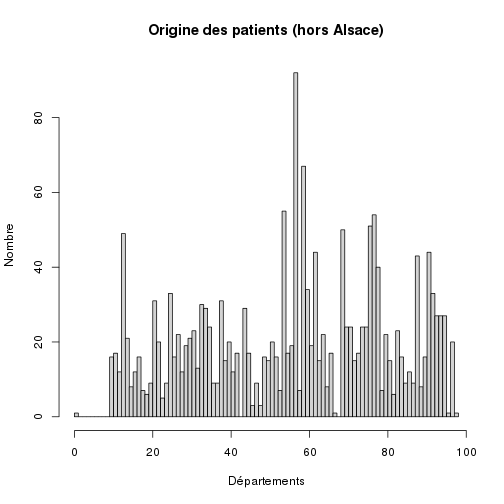

```r
hist(as.integer(dep), breaks = 99, xlab = "Départements", ylab = "Nombre",
    main = "Origine des patients (hors Alsace)", col = "lightgray")
```

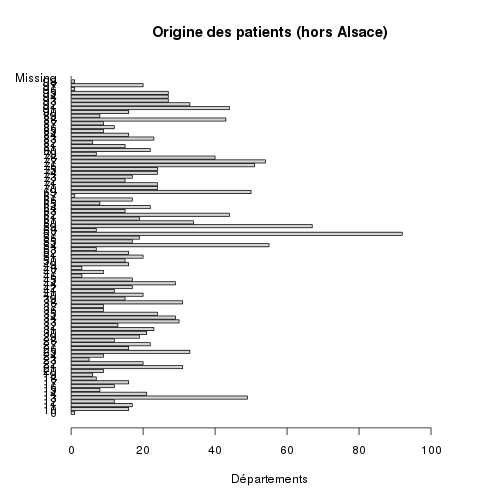

```
## as.integer(dep) :
##         Frequency Percent Cum. percent
## 0               1     0.1          0.1
## 10             16     0.9          0.9
## 11             17     0.9          1.9
## 12             12     0.7          2.5
## 13             49     2.7          5.2
## 14             21     1.1          6.3
## 15              8     0.4          6.8
## 16             12     0.7          7.4
## 17             16     0.9          8.3
## 18              7     0.4          8.7
## 19              6     0.3          9.0
## 20              9     0.5          9.5
## 21             31     1.7         11.2
```

[output cut: 76 more lines]

```r
tab1(as.integer(dep), horiz = TRUE, bar.values = FALSE, xlab = "Départements",
    ylab = "Nombre", main = "Origine des patients (hors Alsace)", col = "lightgray")
```

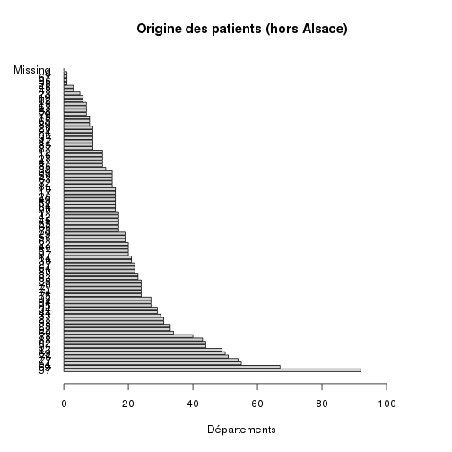

```
## as.integer(dep) :
##         Frequency Percent Cum. percent
## 57             92     5.0          5.0
## 59             67     3.7          8.7
## 54             55     3.0         11.7
## 77             54     2.9         14.6
## 76             51     2.8         17.4
## 69             50     2.7         20.1
## 13             49     2.7         22.8
## 91             44     2.4         25.2
## 62             44     2.4         27.6
## 88             43     2.3         29.9
## 78             40     2.2         32.1
## 60             34     1.9         34.0
## 92             33     1.8         35.7
```

[output cut: 76 more lines]

```r
tab1(as.integer(dep), horiz = TRUE, bar.values = FALSE, sort.group = "decreasing",
    xlab = "Départements", ylab = "Nombre", main = "Origine des patients (hors Alsace)",
    col = "lightgray")
```

# Motifs

% de motifs renseignés

```r
b <- d1$MOTIF
nb <- length(b)
nb
```

```
## [1] 142376
```

```r
c <- b[as.character(b) != "NULL"]
nc <- length(c)
nc
```

```
## [1] 142376
```

```r
round(nc * 100/nb, 2)
```

```
## [1] 100
```

nombre d'items différents:

```r
a <- unique(c)
length(a)
```

```
## [1] 20952
```

# Diagnostic principal

dp = diagnostic principal, ndp = nomdre de dp, dpr = dp renseignés, ndpr = nombre de dpr Les nomenclatures CIM10 ne sont pas homogènes. Ainsi on peut trouver I60.9 ou I609. La méthode *gsub(“.”,“”,a,fixed=TRUE)* permet d'éliminer le point.

```r
dp <- d1$DP
ndp <- length(dp)
dpr <- dp[as.character(dp) != "NULL"]
ndpr <- length(dpr)
round(ndpr * 100/ndp, 2)
```

```
## [1] 100
```

nombre de DP différents:

```r
a <- unique(dpr)
length(a)
```

```
## [1] 5845
```

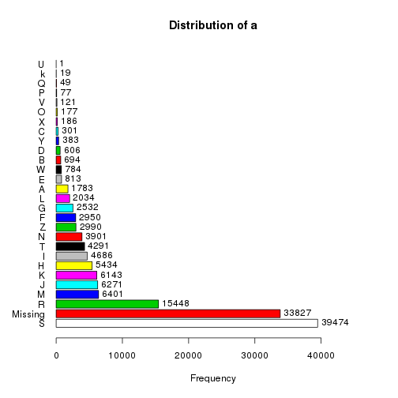

```
## a :
##         Frequency   %(NA+)   %(NA-)
## S           39474     27.7     36.4
## <NA>        33827     23.8      0.0
## R           15448     10.9     14.2
## M            6401      4.5      5.9
## J            6271      4.4      5.8
## K            6143      4.3      5.7
## H            5434      3.8      5.0
## I            4686      3.3      4.3
## T            4291      3.0      4.0
## N            3901      2.7      3.6
## Z            2990      2.1      2.8
## F            2950      2.1      2.7
## G            2532      1.8      2.3
## L            2034      1.4      1.9
## A            1783      1.3      1.6
## E             813      0.6      0.7
## W             784      0.6      0.7
## B             694      0.5      0.6
## D             606      0.4      0.6
## Y             383      0.3      0.4
## C             301      0.2      0.3
## X             186      0.1      0.2
## O             177      0.1      0.2
## V             121      0.1      0.1
## P              77      0.1      0.1
## Q              49      0.0      0.0
## k              19      0.0      0.0
## U               1      0.0      0.0
##   Total    142376    100.0    100.0
```

```r
a <- substr(dpr, 1, 1)
n <- unique(a)
tab1(a, horiz = TRUE, sort.group = "decreasing")
```

## Etude AVC

Les AVC sont définis par la nomenclature *I60* à *I64*, *G45* Accidents ischémiques cérébraux transitoires (sauf G45.4 amnésie transitoire) et syndromes apparentés et *G46* Syndromes vasculaires cérébraux au cours de maladies cérébrovasculaires

La prévention et la prise en charge des accidents vasculaires cérébraux - Annexes - juin 2009

Annexe : Liste exhaustive des codes CIM-10 d’AVC

- G450 Syndrome vertébro-basilaire
- G451 Syndrome carotidien (hémisphérique)
- G452 Accident ischémique transitoire de territoires artériels précérébraux multipleset bilatéraux
- G453 Amaurose fugace
- G454 Amnésie globale transitoire : NON RETENU
- G458 Autres accidents ischémiques cérébraux transitoires et syndromes apparentés
- G459 Accident ischémique cérébral transitoire, sans précision
- I600 Hémorragie sous-arachnoïdienne de labifurcation et du siphon carotidien
- I601 Hémorragie sous-arachnoïdienne de l'artère cérébrale moyenne
- I602 Hémorragie sous-arachnoïdienne de
- l'artère communicante antérieure
- I603 Hémorragie sous-arachnoïdienne del'artère communicante postérieure
- I604 Hémorragie sous-arachnoïdienne de l'artère basilaire
- I605 Hémorragie sous-arachnoïdienne de l'artère vertébrale
- I606 Hémorragie sous-arachnoïdienne d'autres artères intracrâniennes
- I607 Hémorragie sous-arachnoïdienne d'une ar tère intracrânienne, sans précision
- I608 Autres hémorragies sous-arachnoïdiennes
- I609 Hémorragie sous-arachnoïdienne, sans précision
- I610 Hémorragie intracérébrale hémisphérique, sous-corticale
- I611 Hémorragie intracérébrale hémisphérique, corticale
- I612 Hémorragie intracérébrale hémisphérique, non précisée
- I613 Hémorragie intracérébrale du tronc cérébral
- I614 Hémorragie intracérébrale cérébelleuse
- I615 Hémorragie intracérébrale intraventriculaire
- I616 Hémorragie intracérébrale,localisations multiples
- I618 Autres hémorragies intracérébrales
- I619 Hémorragie intracérébrale, sans précision
- I620 Hémorragie sous-durale (aiguë) (non traumatique)
- I621 Hémorragie extradurale non traumatique
- I629 Hémorragie intracrânienne (non traumatique), sans précision
- I630 Infarctus cérébral dû à une thrombose des artères précérébrales
- I631 Infarctus cérébral dû à une embolie des artères précérébrales
- I632 Infarctus cérébral dû à une occlusion ou sténose des artères précérébrales,de mécanisme non précisé
- I633 Infarctus cérébral dû à une thrombose des artères cérébrales
- I634 Infarctus cérébral dû à une embolie des artères cérébrales
- I635 Infarctus cérébral dû à une occlusion ou sténose des artères cérébrales, demécanisme non précisé
- I636 Infarctus cérébral dû à une thrombose veineuse cérébrale, non pyogène
- I638 Autres infarctus cérébraux
- I639 Infarctus cérébral, sans précision
- I64 Accident vasculaire cérébral, non précisé comme étant hémorragique ou parinfarctus
- G460 Syndrome de l'artère cérébrale moyenne (I66.0) (1)
- G461 Syndrome de l'artère cérébrale antérieure (I66.1) (1)
- G462 Syndrome de l'artère cérébrale postérieure (I66.2) (1)
- G463 Syndromes vasculaires du tronc cérébral (I60-I67) (1)
- G464 Syndrome cérébelleux vasculaire (I60-I67) (1)
- G465 Syndrome lacunaire moteur pur (I60-I67) (1)
- G466 Syndrome lacunaire sensitif pur (I60-I67) (1)
- G467 Autres syndromes lacunaires (I60-I67) (1)
- G468 Autres syndromes vasculaires cérébraux au cours de maladies cérébrovasculaires (I60-I67) (1) (1) : résumé à ne retenir que si présence d’un diagnostic associé significatif (DAS) des catégories I60 à I64

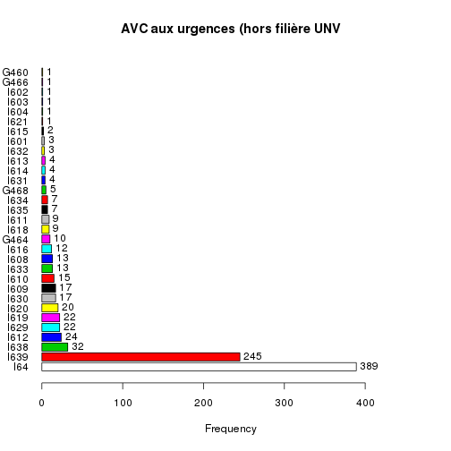

```
## a :
##         Frequency   %(NA+)   %(NA-)
## <NA>        33827     97.4      0.0
## I64           389      1.1     42.6
## I639          245      0.7     26.8
## I638           32      0.1      3.5
## I612           24      0.1      2.6
## I619           22      0.1      2.4
## I629           22      0.1      2.4
## I620           20      0.1      2.2
## I609           17      0.0      1.9
## I630           17      0.0      1.9
## I610           15      0.0      1.6
## I608           13      0.0      1.4
## I633           13      0.0      1.4
## I616           12      0.0      1.3
## G464           10      0.0      1.1
## I611            9      0.0      1.0
## I618            9      0.0      1.0
## I634            7      0.0      0.8
## I635            7      0.0      0.8
## G468            5      0.0      0.5
## I613            4      0.0      0.4
## I614            4      0.0      0.4
## I631            4      0.0      0.4
## I601            3      0.0      0.3
## I632            3      0.0      0.3
## I615            2      0.0      0.2
## G460            1      0.0      0.1
## G466            1      0.0      0.1
## I602            1      0.0      0.1
## I603            1      0.0      0.1
## I604            1      0.0      0.1
## I621            1      0.0      0.1
##   Total     34741    100.0    100.0
```

```r
avc <- dpr[substr(dpr, 1, 3) >= "I60" & substr(dpr, 1, 3) < "I65" | substr(dpr,
    1, 3) == "G46"]
navc <- unique(avc)
a <- as.character(avc)
a <- gsub(".", "", a, fixed = TRUE)
tab1(a, horiz = TRUE, sort.group = "decreasing", main = "AVC aux urgences (hors filière UNV",
    missing = FALSE)
```

```r
avc_ait <- dpr[substr(dpr, 1, 3) >= "I60" & substr(dpr, 1, 3) < "I65" | substr(dpr,
    1, 3) == "G46" | substr(dpr, 1, 3) == "G45"]
```

###on crée un dataframe avec 10 colonnes:

```r
CIM10 <- d1[as.character(d1$DP) != "NULL", c("DP", "CODE_POSTAL", "ENTREE",
    "FINESS", "GRAVITE", "ORIENTATION", "MODE_SORTIE", "AGE", "SEXE", "TRANSPORT")]
```

On corrige DP en supprimmant les points et les plus:

```r
CIM10$DP <- gsub(".", "", as.character(CIM10$DP), fixed = TRUE)
CIM10$DP <- gsub("+", "", as.character(CIM10$DP), fixed = TRUE)
```

Création d'un dataframe AVC:

```r
CIM10$DP <- as.character(CIM10$DP)
AVC <- CIM10[substr(CIM10$DP, 1, 3) >= "I60" & substr(CIM10$DP, 1, 3) < "I65" |
    substr(CIM10$DP, 1, 3) == "G46" | substr(CIM10$DP, 1, 3) == "G45", ]
```

Heures AVC

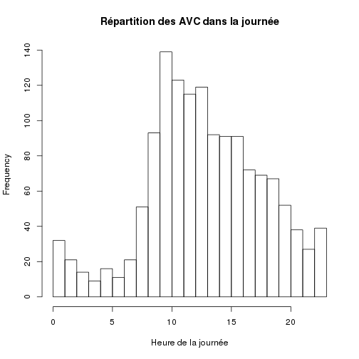

```r
h <- hour(AVC$ENTREE)
hist(h, breaks = 24, xlab = "Heure de la journée", main = "Répartition des AVC dans la journée")
```

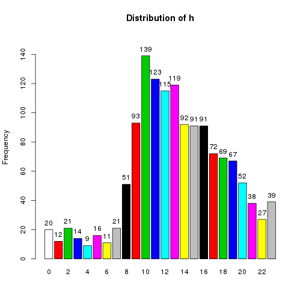

```
## h :
##         Frequency   %(NA+)   %(NA-)
## 0              20      0.1      1.4
## 1              12      0.0      0.9
## 2              21      0.1      1.5
## 3              14      0.0      1.0
## 4               9      0.0      0.6
## 5              16      0.0      1.1
## 6              11      0.0      0.8
## 7              21      0.1      1.5
## 8              51      0.1      3.6
## 9              93      0.3      6.6
## 10            139      0.4      9.9
## 11            123      0.3      8.8
## 12            115      0.3      8.2
## 13            119      0.3      8.5
## 14             92      0.3      6.6
## 15             91      0.3      6.5
## 16             91      0.3      6.5
## 17             72      0.2      5.1
## 18             69      0.2      4.9
## 19             67      0.2      4.8
## 20             52      0.1      3.7
## 21             38      0.1      2.7
## 22             27      0.1      1.9
## 23             39      0.1      2.8
## <NA>        33827     96.0      0.0
##   Total     35229    100.0    100.0
```

```r
tab1(h, missing = FALSE)
```

Jour de la semaine:

```r
w <- wday(AVC$ENTREE, label = TRUE)
table(w)
```

```
## w
##   Sun   Mon  Tues   Wed Thurs   Fri   Sat
##   178   219   198   163   217   237   190
```

```r
round(prop.table(table(w)) * 100, 2)
```

```
## w
##   Sun   Mon  Tues   Wed Thurs   Fri   Sat
## 12.70 15.62 14.12 11.63 15.48 16.90 13.55
```

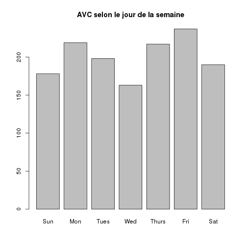

```r
plot(w, main = "AVC selon le jour de la semaine")
```

## Etude AIT

Recommandations pour la sélection des données PMSI MCO concernant l’AVC (Juin 2009)

- G450 Syndrome vertébro-basilaire
- G451 Syndrome carotidien (hémisphérique)
- G452 Accident ischémique transitoire de territoires artériels précérébraux multiples et bilatéraux
- G453 Amaurose fugace
- G458 Autres accidents ischémiques cérébraux transitoires et syndromes apparentés
- G459 Accident ischémique cérébral transitoire, sans précision

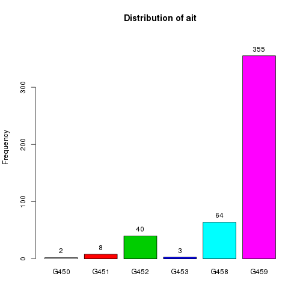

```
## ait :
##         Frequency   %(NA+)   %(NA-)
## G450            2      0.0      0.4
## G451            8      0.0      1.7
## G452           40      0.1      8.5
## G453            3      0.0      0.6
## G458           64      0.2     13.6
## G459          355      1.0     75.2
## <NA>        33827     98.6      0.0
##   Total     34299    100.0    100.0
```

```r
ait <- CIM10$DP[substr(CIM10$DP, 1, 3) == "G45" & substr(CIM10$DP, 1, 4) !=
    "G454"]
tab1(ait, missing = FALSE)
```

## Age et AVC

```r
summary(AVC$AGE)
```

```
##    Min. 1st Qu.  Median    Mean 3rd Qu.    Max.    NA's
##       8      62      76      72      83     101   33827
```

Le rapport de 2009 donne age moyen = 70.5 et age médian = 75 ans.

## Sexe et AVC

```r
a <- factor(AVC$SEXE)
summary(a)
```

```
##     F     M  NA's
##   727   675 33827
```

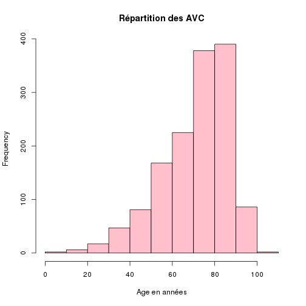

```r
hist(AVC$AGE, main = "Répartition des AVC", col = "pink", xlab = "Age en années")
```

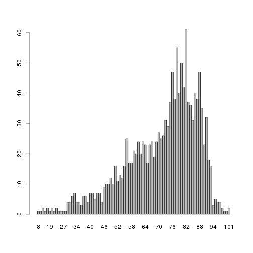

```r
t <- table(AVC$AGE)
barplot(t)
```

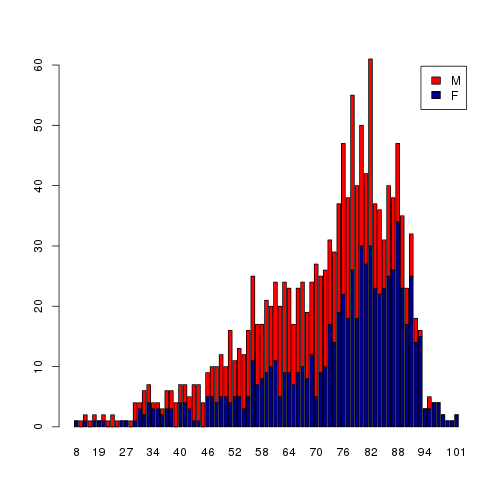

```r
t <- table(a, AVC$AGE)
barplot(t, col = c("darkblue", "red"), legend = TRUE)
```

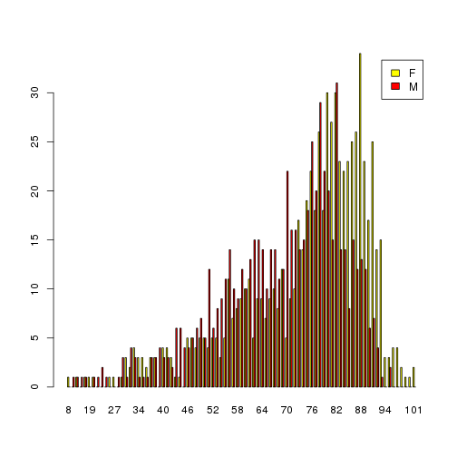

```r
barplot(t, col = c("yellow", "red"), legend = TRUE, beside = TRUE)
```